# Risk Factor Analysis

## Outcome Variable

**Outcome Variable:** ever_co

## Predictor Variables

**Intervention Variable:** mbmi

**Adjustment Set:**

- arm
- W_mage
- meducyrs
- feducyrs
- hhwealth_quart
- W_nchldlt5
- brthmon
- W_parity
- delta_W_mage
- delta_meducyrs
- delta_feducyrs
- delta_hhwealth_quart
- delta_W_nchldlt5
- delta_brthmon
- delta_W_parity

## Stratifying Variables

The analysis was stratified on these variable(s):

- agecat
- studyid
- country

## Data Summary

| agecat | studyid | country | mbmi | ever_co | n_cell | n |
| --- | --- | --- | --- | --- | --- | --- |
| 0-24 months | ki0047075b-MAL-ED | BANGLADESH | Normal weight | 0 | 194 | 254 |
| 0-24 months | ki0047075b-MAL-ED | BANGLADESH | Normal weight | 1 | 28 | 254 |
| 0-24 months | ki0047075b-MAL-ED | BANGLADESH | Underweight | 0 | 21 | 254 |
| 0-24 months | ki0047075b-MAL-ED | BANGLADESH | Underweight | 1 | 11 | 254 |
| 0-24 months | ki0047075b-MAL-ED | BRAZIL | Normal weight | 0 | 209 | 221 |
| 0-24 months | ki0047075b-MAL-ED | BRAZIL | Normal weight | 1 | 2 | 221 |
| 0-24 months | ki0047075b-MAL-ED | BRAZIL | Underweight | 0 | 10 | 221 |
| 0-24 months | ki0047075b-MAL-ED | BRAZIL | Underweight | 1 | 0 | 221 |
| 0-24 months | ki0047075b-MAL-ED | INDIA | Normal weight | 0 | 154 | 242 |
| 0-24 months | ki0047075b-MAL-ED | INDIA | Normal weight | 1 | 39 | 242 |
| 0-24 months | ki0047075b-MAL-ED | INDIA | Underweight | 0 | 35 | 242 |
| 0-24 months | ki0047075b-MAL-ED | INDIA | Underweight | 1 | 14 | 242 |
| 0-24 months | ki0047075b-MAL-ED | NEPAL | Normal weight | 0 | 216 | 238 |
| 0-24 months | ki0047075b-MAL-ED | NEPAL | Normal weight | 1 | 22 | 238 |
| 0-24 months | ki0047075b-MAL-ED | NEPAL | Underweight | 0 | 0 | 238 |
| 0-24 months | ki0047075b-MAL-ED | NEPAL | Underweight | 1 | 0 | 238 |
| 0-24 months | ki0047075b-MAL-ED | PERU | Normal weight | 0 | 275 | 290 |
| 0-24 months | ki0047075b-MAL-ED | PERU | Normal weight | 1 | 10 | 290 |
| 0-24 months | ki0047075b-MAL-ED | PERU | Underweight | 0 | 3 | 290 |
| 0-24 months | ki0047075b-MAL-ED | PERU | Underweight | 1 | 2 | 290 |
| 0-24 months | ki0047075b-MAL-ED | SOUTH AFRICA | Normal weight | 0 | 241 | 270 |
| 0-24 months | ki0047075b-MAL-ED | SOUTH AFRICA | Normal weight | 1 | 21 | 270 |
| 0-24 months | ki0047075b-MAL-ED | SOUTH AFRICA | Underweight | 0 | 8 | 270 |
| 0-24 months | ki0047075b-MAL-ED | SOUTH AFRICA | Underweight | 1 | 0 | 270 |
| 0-24 months | ki0047075b-MAL-ED | TANZANIA, UNITED REPUBLIC OF | Normal weight | 0 | 222 | 256 |
| 0-24 months | ki0047075b-MAL-ED | TANZANIA, UNITED REPUBLIC OF | Normal weight | 1 | 20 | 256 |
| 0-24 months | ki0047075b-MAL-ED | TANZANIA, UNITED REPUBLIC OF | Underweight | 0 | 11 | 256 |
| 0-24 months | ki0047075b-MAL-ED | TANZANIA, UNITED REPUBLIC OF | Underweight | 1 | 3 | 256 |
| 0-24 months | ki1000304b-SAS-CompFeed | INDIA | Normal weight | 0 | 819 | 1390 |
| 0-24 months | ki1000304b-SAS-CompFeed | INDIA | Normal weight | 1 | 200 | 1390 |

[output cut: 170 more lines]

The following strata were considered:

- agecat: 0-24 months, studyid: ki0047075b-MAL-ED, country: BANGLADESH
- agecat: 0-24 months, studyid: ki0047075b-MAL-ED, country: BRAZIL
- agecat: 0-24 months, studyid: ki0047075b-MAL-ED, country: INDIA
- agecat: 0-24 months, studyid: ki0047075b-MAL-ED, country: NEPAL
- agecat: 0-24 months, studyid: ki0047075b-MAL-ED, country: PERU
- agecat: 0-24 months, studyid: ki0047075b-MAL-ED, country: SOUTH AFRICA
- agecat: 0-24 months, studyid: ki0047075b-MAL-ED, country: TANZANIA, UNITED REPUBLIC OF
- agecat: 0-24 months, studyid: ki1000304b-SAS-CompFeed, country: INDIA
- agecat: 0-24 months, studyid: ki1017093-NIH-Birth, country: BANGLADESH
- agecat: 0-24 months, studyid: ki1017093b-PROVIDE, country: BANGLADESH
- agecat: 0-24 months, studyid: ki1017093c-NIH-Crypto, country: BANGLADESH
- agecat: 0-24 months, studyid: ki1066203-TanzaniaChild2, country: TANZANIA, UNITED REPUBLIC OF
- agecat: 0-24 months, studyid: ki1112895-iLiNS-Zinc, country: BURKINA FASO
- agecat: 0-24 months, studyid: ki1119695-PROBIT, country: BELARUS
- agecat: 0-24 months, studyid: ki1126311-ZVITAMBO, country: ZIMBABWE
- agecat: 0-24 months, studyid: ki1148112-LCNI-5, country: MALAWI
- agecat: 0-24 months, studyid: kiGH5241-JiVitA-3, country: BANGLADESH
- agecat: 0-6 months, studyid: ki0047075b-MAL-ED, country: BANGLADESH
- agecat: 0-6 months, studyid: ki0047075b-MAL-ED, country: BRAZIL
- agecat: 0-6 months, studyid: ki0047075b-MAL-ED, country: INDIA
- agecat: 0-6 months, studyid: ki0047075b-MAL-ED, country: NEPAL
- agecat: 0-6 months, studyid: ki0047075b-MAL-ED, country: PERU
- agecat: 0-6 months, studyid: ki0047075b-MAL-ED, country: SOUTH AFRICA
- agecat: 0-6 months, studyid: ki0047075b-MAL-ED, country: TANZANIA, UNITED REPUBLIC OF
- agecat: 0-6 months, studyid: ki1000304b-SAS-CompFeed, country: INDIA
- agecat: 0-6 months, studyid: ki1017093-NIH-Birth, country: BANGLADESH
- agecat: 0-6 months, studyid: ki1017093b-PROVIDE, country: BANGLADESH
- agecat: 0-6 months, studyid: ki1017093c-NIH-Crypto, country: BANGLADESH
- agecat: 0-6 months, studyid: ki1066203-TanzaniaChild2, country: TANZANIA, UNITED REPUBLIC OF
- agecat: 0-6 months, studyid: ki1119695-PROBIT, country: BELARUS
- agecat: 0-6 months, studyid: ki1126311-ZVITAMBO, country: ZIMBABWE
- agecat: 0-6 months, studyid: ki1148112-LCNI-5, country: MALAWI
- agecat: 0-6 months, studyid: kiGH5241-JiVitA-3, country: BANGLADESH
- agecat: 6-24 months, studyid: ki0047075b-MAL-ED, country: BANGLADESH
- agecat: 6-24 months, studyid: ki0047075b-MAL-ED, country: BRAZIL
- agecat: 6-24 months, studyid: ki0047075b-MAL-ED, country: INDIA
- agecat: 6-24 months, studyid: ki0047075b-MAL-ED, country: NEPAL
- agecat: 6-24 months, studyid: ki0047075b-MAL-ED, country: PERU
- agecat: 6-24 months, studyid: ki0047075b-MAL-ED, country: SOUTH AFRICA
- agecat: 6-24 months, studyid: ki0047075b-MAL-ED, country: TANZANIA, UNITED REPUBLIC OF
- agecat: 6-24 months, studyid: ki1000304b-SAS-CompFeed, country: INDIA
- agecat: 6-24 months, studyid: ki1017093-NIH-Birth, country: BANGLADESH
- agecat: 6-24 months, studyid: ki1017093b-PROVIDE, country: BANGLADESH
- agecat: 6-24 months, studyid: ki1017093c-NIH-Crypto, country: BANGLADESH
- agecat: 6-24 months, studyid: ki1066203-TanzaniaChild2, country: TANZANIA, UNITED REPUBLIC OF
- agecat: 6-24 months, studyid: ki1112895-iLiNS-Zinc, country: BURKINA FASO
- agecat: 6-24 months, studyid: ki1119695-PROBIT, country: BELARUS
- agecat: 6-24 months, studyid: ki1126311-ZVITAMBO, country: ZIMBABWE
- agecat: 6-24 months, studyid: ki1148112-LCNI-5, country: MALAWI
- agecat: 6-24 months, studyid: kiGH5241-JiVitA-3, country: BANGLADESH

### Dropped Strata

Some strata were dropped due to rare outcomes:

- agecat: 0-24 months, studyid: ki0047075b-MAL-ED, country: BRAZIL
- agecat: 0-24 months, studyid: ki0047075b-MAL-ED, country: NEPAL
- agecat: 0-24 months, studyid: ki0047075b-MAL-ED, country: PERU
- agecat: 0-24 months, studyid: ki0047075b-MAL-ED, country: SOUTH AFRICA
- agecat: 0-24 months, studyid: ki0047075b-MAL-ED, country: TANZANIA, UNITED REPUBLIC OF
- agecat: 0-24 months, studyid: ki1066203-TanzaniaChild2, country: TANZANIA, UNITED REPUBLIC OF
- agecat: 0-24 months, studyid: ki1119695-PROBIT, country: BELARUS
- agecat: 0-6 months, studyid: ki0047075b-MAL-ED, country: BANGLADESH
- agecat: 0-6 months, studyid: ki0047075b-MAL-ED, country: BRAZIL
- agecat: 0-6 months, studyid: ki0047075b-MAL-ED, country: NEPAL
- agecat: 0-6 months, studyid: ki0047075b-MAL-ED, country: PERU
- agecat: 0-6 months, studyid: ki0047075b-MAL-ED, country: SOUTH AFRICA
- agecat: 0-6 months, studyid: ki0047075b-MAL-ED, country: TANZANIA, UNITED REPUBLIC OF
- agecat: 0-6 months, studyid: ki1017093c-NIH-Crypto, country: BANGLADESH
- agecat: 0-6 months, studyid: ki1066203-TanzaniaChild2, country: TANZANIA, UNITED REPUBLIC OF
- agecat: 0-6 months, studyid: ki1119695-PROBIT, country: BELARUS
- agecat: 0-6 months, studyid: ki1148112-LCNI-5, country: MALAWI
- agecat: 6-24 months, studyid: ki0047075b-MAL-ED, country: BRAZIL
- agecat: 6-24 months, studyid: ki0047075b-MAL-ED, country: NEPAL
- agecat: 6-24 months, studyid: ki0047075b-MAL-ED, country: PERU
- agecat: 6-24 months, studyid: ki0047075b-MAL-ED, country: SOUTH AFRICA
- agecat: 6-24 months, studyid: ki0047075b-MAL-ED, country: TANZANIA, UNITED REPUBLIC OF
- agecat: 6-24 months, studyid: ki1066203-TanzaniaChild2, country: TANZANIA, UNITED REPUBLIC OF
- agecat: 6-24 months, studyid: ki1119695-PROBIT, country: BELARUS

## Methods Detail

We’re interested in the causal parameters $E[Y_a]$ for all values of $a \in \mathcal{A}$. These parameters represent the mean outcome if, possibly contrary to fact, we intervened to set all units to have $A=a$. Under the randomization and positivity assumptions, these are identified by the statistical parameters $\psi_a=E_W[E_{Y|A,W}(Y|A=a,W)]$. In addition, we’re interested in the mean of $Y$, $E[Y]$ under no intervention (the observed mean). We will estimate these parameters by using SuperLearner to fit the relevant likelihood factors – $E_{Y|A,W}(Y|A=a,W)$ and $p(A=a|W)$, and then updating our likelihood fit using a joint TMLE.

For unadjusted analyses ($W=\{\}$), initial likelihoods were estimated using Lrnr_glm to estimate the simple $E(Y|A)$ and Lrnr_mean to estimate $p(A)$. For adjusted analyses, a small library containing Lrnr_glmnet, Lrnr_xgboost, and Lrnr_mean was used.

Having estimated these parameters, we will then use the delta method to estimate relative risks and attributable risks relative to a prespecified baseline level of $A$.

# Results Detail

## Results Plots

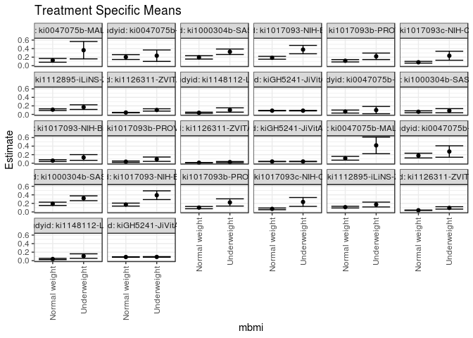

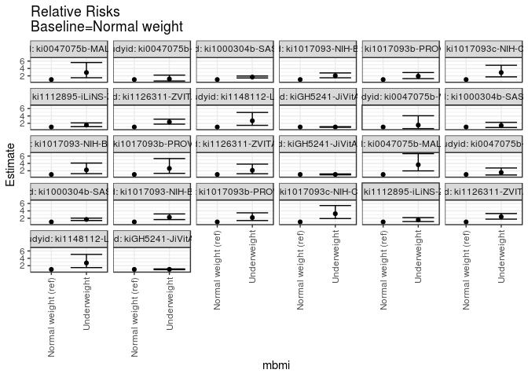

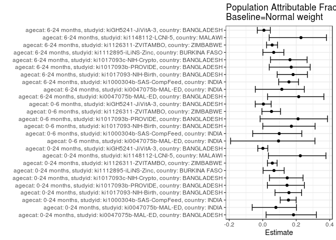

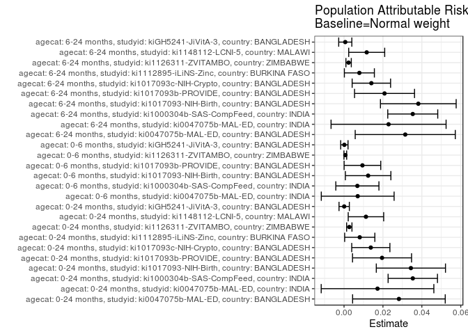

## Results Table

### Parameter: TSM

| agecat | studyid | country | intervention_level | baseline_level | estimate | ci_lower | ci_upper |
| --- | --- | --- | --- | --- | --- | --- | --- |
| 0-24 months | ki0047075b-MAL-ED | BANGLADESH | Normal weight | NA | 0.1253254 | 0.0812003 | 0.1694505 |
| 0-24 months | ki0047075b-MAL-ED | BANGLADESH | Underweight | NA | 0.3633739 | 0.1595667 | 0.5671811 |
| 0-24 months | ki0047075b-MAL-ED | INDIA | Normal weight | NA | 0.2017920 | 0.1448281 | 0.2587558 |
| 0-24 months | ki0047075b-MAL-ED | INDIA | Underweight | NA | 0.2342062 | 0.1004418 | 0.3679707 |
| 0-24 months | ki1000304b-SAS-CompFeed | INDIA | Normal weight | NA | 0.1948673 | 0.1552322 | 0.2345025 |
| 0-24 months | ki1000304b-SAS-CompFeed | INDIA | Underweight | NA | 0.3257777 | 0.2614398 | 0.3901156 |
| 0-24 months | ki1017093-NIH-Birth | BANGLADESH | Normal weight | NA | 0.1851826 | 0.1516648 | 0.2187003 |
| 0-24 months | ki1017093-NIH-Birth | BANGLADESH | Underweight | NA | 0.3768819 | 0.2793008 | 0.4744630 |
| 0-24 months | ki1017093b-PROVIDE | BANGLADESH | Normal weight | NA | 0.1149924 | 0.0879926 | 0.1419922 |
| 0-24 months | ki1017093b-PROVIDE | BANGLADESH | Underweight | NA | 0.2193264 | 0.1432841 | 0.2953687 |
| 0-24 months | ki1017093c-NIH-Crypto | BANGLADESH | Normal weight | NA | 0.0802747 | 0.0599379 | 0.1006115 |
| 0-24 months | ki1017093c-NIH-Crypto | BANGLADESH | Underweight | NA | 0.2329468 | 0.1273880 | 0.3385055 |
| 0-24 months | ki1112895-iLiNS-Zinc | BURKINA FASO | Normal weight | NA | 0.1119462 | 0.0922969 | 0.1315955 |
| 0-24 months | ki1112895-iLiNS-Zinc | BURKINA FASO | Underweight | NA | 0.1707870 | 0.1163147 | 0.2252593 |
| 0-24 months | ki1126311-ZVITAMBO | ZIMBABWE | Normal weight | NA | 0.0442624 | 0.0400735 | 0.0484513 |
| 0-24 months | ki1126311-ZVITAMBO | ZIMBABWE | Underweight | NA | 0.1046708 | 0.0771267 | 0.1322148 |
| 0-24 months | ki1148112-LCNI-5 | MALAWI | Normal weight | NA | 0.0389154 | 0.0244765 | 0.0533542 |
| 0-24 months | ki1148112-LCNI-5 | MALAWI | Underweight | NA | 0.1045680 | 0.0537843 | 0.1553516 |
| 0-24 months | kiGH5241-JiVitA-3 | BANGLADESH | Normal weight | NA | 0.0888717 | 0.0840336 | 0.0937098 |
| 0-24 months | kiGH5241-JiVitA-3 | BANGLADESH | Underweight | NA | 0.0890664 | 0.0833655 | 0.0947673 |
| 0-6 months | ki0047075b-MAL-ED | INDIA | Normal weight | NA | 0.0673575 | 0.0319236 | 0.1027914 |
| 0-6 months | ki0047075b-MAL-ED | INDIA | Underweight | NA | 0.1020408 | 0.0171102 | 0.1869715 |
| 0-6 months | ki1000304b-SAS-CompFeed | INDIA | Normal weight | NA | 0.0626129 | 0.0403561 | 0.0848698 |
| 0-6 months | ki1000304b-SAS-CompFeed | INDIA | Underweight | NA | 0.0878116 | 0.0400469 | 0.1355764 |
| 0-6 months | ki1017093-NIH-Birth | BANGLADESH | Normal weight | NA | 0.0599626 | 0.0395211 | 0.0804040 |
| 0-6 months | ki1017093-NIH-Birth | BANGLADESH | Underweight | NA | 0.1339257 | 0.0668085 | 0.2010429 |
| 0-6 months | ki1017093b-PROVIDE | BANGLADESH | Normal weight | NA | 0.0353887 | 0.0198922 | 0.0508851 |
| 0-6 months | ki1017093b-PROVIDE | BANGLADESH | Underweight | NA | 0.0933772 | 0.0423646 | 0.1443899 |
| 0-6 months | ki1126311-ZVITAMBO | ZIMBABWE | Normal weight | NA | 0.0117520 | 0.0095557 | 0.0139483 |
| 0-6 months | ki1126311-ZVITAMBO | ZIMBABWE | Underweight | NA | 0.0250273 | 0.0113012 | 0.0387534 |
| 0-6 months | kiGH5241-JiVitA-3 | BANGLADESH | Normal weight | NA | 0.0394682 | 0.0363174 | 0.0426191 |
| 0-6 months | kiGH5241-JiVitA-3 | BANGLADESH | Underweight | NA | 0.0398934 | 0.0359575 | 0.0438293 |
| 6-24 months | ki0047075b-MAL-ED | BANGLADESH | Normal weight | NA | 0.1149756 | 0.0709265 | 0.1590247 |
| 6-24 months | ki0047075b-MAL-ED | BANGLADESH | Underweight | NA | 0.4171349 | 0.2217208 | 0.6125491 |
| 6-24 months | ki0047075b-MAL-ED | INDIA | Normal weight | NA | 0.1779601 | 0.1227317 | 0.2331885 |
| 6-24 months | ki0047075b-MAL-ED | INDIA | Underweight | NA | 0.2732899 | 0.1389769 | 0.4076029 |
| 6-24 months | ki1000304b-SAS-CompFeed | INDIA | Normal weight | NA | 0.1902044 | 0.1515857 | 0.2288231 |
| 6-24 months | ki1000304b-SAS-CompFeed | INDIA | Underweight | NA | 0.3203367 | 0.2641083 | 0.3765651 |
| 6-24 months | ki1017093-NIH-Birth | BANGLADESH | Normal weight | NA | 0.1721506 | 0.1370542 | 0.2072470 |
| 6-24 months | ki1017093-NIH-Birth | BANGLADESH | Underweight | NA | 0.3917609 | 0.2893039 | 0.4942179 |
| 6-24 months | ki1017093b-PROVIDE | BANGLADESH | Normal weight | NA | 0.1015307 | 0.0749760 | 0.1280854 |
| 6-24 months | ki1017093b-PROVIDE | BANGLADESH | Underweight | NA | 0.2222745 | 0.1376826 | 0.3068663 |
| 6-24 months | ki1017093c-NIH-Crypto | BANGLADESH | Normal weight | NA | 0.0722535 | 0.0525325 | 0.0919745 |
| 6-24 months | ki1017093c-NIH-Crypto | BANGLADESH | Underweight | NA | 0.2337620 | 0.1300480 | 0.3374759 |
| 6-24 months | ki1112895-iLiNS-Zinc | BURKINA FASO | Normal weight | NA | 0.1121451 | 0.0924364 | 0.1318538 |
| 6-24 months | ki1112895-iLiNS-Zinc | BURKINA FASO | Underweight | NA | 0.1734694 | 0.1165859 | 0.2303529 |
| 6-24 months | ki1126311-ZVITAMBO | ZIMBABWE | Normal weight | NA | 0.0393045 | 0.0350789 | 0.0435300 |
| 6-24 months | ki1126311-ZVITAMBO | ZIMBABWE | Underweight | NA | 0.0942973 | 0.0665627 | 0.1220318 |
| 6-24 months | ki1148112-LCNI-5 | MALAWI | Normal weight | NA | 0.0393803 | 0.0247688 | 0.0539919 |
| 6-24 months | ki1148112-LCNI-5 | MALAWI | Underweight | NA | 0.1082356 | 0.0555771 | 0.1608941 |
| 6-24 months | kiGH5241-JiVitA-3 | BANGLADESH | Normal weight | NA | 0.0862636 | 0.0802451 | 0.0922822 |
| 6-24 months | kiGH5241-JiVitA-3 | BANGLADESH | Underweight | NA | 0.0879110 | 0.0810604 | 0.0947615 |

### Parameter: E(Y)

| agecat | studyid | country | intervention_level | baseline_level | estimate | ci_lower | ci_upper |
| --- | --- | --- | --- | --- | --- | --- | --- |
| 0-24 months | ki0047075b-MAL-ED | BANGLADESH | NA | NA | 0.1535433 | 0.1091205 | 0.1979661 |
| 0-24 months | ki0047075b-MAL-ED | INDIA | NA | NA | 0.2190083 | 0.1667935 | 0.2712230 |
| 0-24 months | ki1000304b-SAS-CompFeed | INDIA | NA | NA | 0.2302158 | 0.1856981 | 0.2747335 |
| 0-24 months | ki1017093-NIH-Birth | BANGLADESH | NA | NA | 0.2195513 | 0.1870467 | 0.2520558 |
| 0-24 months | ki1017093b-PROVIDE | BANGLADESH | NA | NA | 0.1345291 | 0.1086533 | 0.1604050 |
| 0-24 months | ki1017093c-NIH-Crypto | BANGLADESH | NA | NA | 0.0940397 | 0.0732057 | 0.1148737 |
| 0-24 months | ki1112895-iLiNS-Zinc | BURKINA FASO | NA | NA | 0.1200249 | 0.0999720 | 0.1400777 |
| 0-24 months | ki1126311-ZVITAMBO | ZIMBABWE | NA | NA | 0.0469627 | 0.0427729 | 0.0511526 |
| 0-24 months | ki1148112-LCNI-5 | MALAWI | NA | NA | 0.0501792 | 0.0353804 | 0.0649781 |
| 0-24 months | kiGH5241-JiVitA-3 | BANGLADESH | NA | NA | 0.0889453 | 0.0850200 | 0.0928705 |
| 0-6 months | ki0047075b-MAL-ED | INDIA | NA | NA | 0.0743802 | 0.0412530 | 0.1075073 |
| 0-6 months | ki1000304b-SAS-CompFeed | INDIA | NA | NA | 0.0694645 | 0.0441638 | 0.0947653 |
| 0-6 months | ki1017093-NIH-Birth | BANGLADESH | NA | NA | 0.0723473 | 0.0519719 | 0.0927227 |
| 0-6 months | ki1017093b-PROVIDE | BANGLADESH | NA | NA | 0.0448430 | 0.0291486 | 0.0605375 |
| 0-6 months | ki1126311-ZVITAMBO | ZIMBABWE | NA | NA | 0.0124026 | 0.0102064 | 0.0145989 |
| 0-6 months | kiGH5241-JiVitA-3 | BANGLADESH | NA | NA | 0.0396314 | 0.0371179 | 0.0421449 |
| 6-24 months | ki0047075b-MAL-ED | BANGLADESH | NA | NA | 0.1464435 | 0.1015265 | 0.1913605 |
| 6-24 months | ki0047075b-MAL-ED | INDIA | NA | NA | 0.2008547 | 0.1494120 | 0.2522974 |
| 6-24 months | ki1000304b-SAS-CompFeed | INDIA | NA | NA | 0.2255286 | 0.1871466 | 0.2639106 |
| 6-24 months | ki1017093-NIH-Birth | BANGLADESH | NA | NA | 0.2103321 | 0.1759902 | 0.2446740 |
| 6-24 months | ki1017093b-PROVIDE | BANGLADESH | NA | NA | 0.1223491 | 0.0963874 | 0.1483108 |
| 6-24 months | ki1017093c-NIH-Crypto | BANGLADESH | NA | NA | 0.0863014 | 0.0659171 | 0.1066856 |
| 6-24 months | ki1112895-iLiNS-Zinc | BURKINA FASO | NA | NA | 0.1200249 | 0.0999720 | 0.1400777 |
| 6-24 months | ki1126311-ZVITAMBO | ZIMBABWE | NA | NA | 0.0416521 | 0.0374281 | 0.0458762 |
| 6-24 months | ki1148112-LCNI-5 | MALAWI | NA | NA | 0.0510328 | 0.0359888 | 0.0660768 |
| 6-24 months | kiGH5241-JiVitA-3 | BANGLADESH | NA | NA | 0.0868934 | 0.0822223 | 0.0915646 |

### Parameter: RR

| agecat | studyid | country | intervention_level | baseline_level | estimate | ci_lower | ci_upper |
| --- | --- | --- | --- | --- | --- | --- | --- |
| 0-24 months | ki0047075b-MAL-ED | BANGLADESH | Normal weight | Normal weight | 1.000000 | 1.0000000 | 1.000000 |
| 0-24 months | ki0047075b-MAL-ED | BANGLADESH | Underweight | Normal weight | 2.899443 | 1.4963385 | 5.618226 |
| 0-24 months | ki0047075b-MAL-ED | INDIA | Normal weight | Normal weight | 1.000000 | 1.0000000 | 1.000000 |
| 0-24 months | ki0047075b-MAL-ED | INDIA | Underweight | Normal weight | 1.160632 | 0.6120396 | 2.200947 |
| 0-24 months | ki1000304b-SAS-CompFeed | INDIA | Normal weight | Normal weight | 1.000000 | 1.0000000 | 1.000000 |
| 0-24 months | ki1000304b-SAS-CompFeed | INDIA | Underweight | Normal weight | 1.671792 | 1.4298729 | 1.954642 |
| 0-24 months | ki1017093-NIH-Birth | BANGLADESH | Normal weight | Normal weight | 1.000000 | 1.0000000 | 1.000000 |
| 0-24 months | ki1017093-NIH-Birth | BANGLADESH | Underweight | Normal weight | 2.035191 | 1.4827635 | 2.793435 |
| 0-24 months | ki1017093b-PROVIDE | BANGLADESH | Normal weight | Normal weight | 1.000000 | 1.0000000 | 1.000000 |
| 0-24 months | ki1017093b-PROVIDE | BANGLADESH | Underweight | Normal weight | 1.907312 | 1.2542646 | 2.900376 |
| 0-24 months | ki1017093c-NIH-Crypto | BANGLADESH | Normal weight | Normal weight | 1.000000 | 1.0000000 | 1.000000 |
| 0-24 months | ki1017093c-NIH-Crypto | BANGLADESH | Underweight | Normal weight | 2.901870 | 1.7264473 | 4.877561 |
| 0-24 months | ki1112895-iLiNS-Zinc | BURKINA FASO | Normal weight | Normal weight | 1.000000 | 1.0000000 | 1.000000 |
| 0-24 months | ki1112895-iLiNS-Zinc | BURKINA FASO | Underweight | Normal weight | 1.525616 | 1.0958445 | 2.123938 |
| 0-24 months | ki1126311-ZVITAMBO | ZIMBABWE | Normal weight | Normal weight | 1.000000 | 1.0000000 | 1.000000 |
| 0-24 months | ki1126311-ZVITAMBO | ZIMBABWE | Underweight | Normal weight | 2.364777 | 1.7878743 | 3.127832 |
| 0-24 months | ki1148112-LCNI-5 | MALAWI | Normal weight | Normal weight | 1.000000 | 1.0000000 | 1.000000 |
| 0-24 months | ki1148112-LCNI-5 | MALAWI | Underweight | Normal weight | 2.687061 | 1.4579167 | 4.952476 |
| 0-24 months | kiGH5241-JiVitA-3 | BANGLADESH | Normal weight | Normal weight | 1.000000 | 1.0000000 | 1.000000 |
| 0-24 months | kiGH5241-JiVitA-3 | BANGLADESH | Underweight | Normal weight | 1.002191 | 0.9268660 | 1.083638 |
| 0-6 months | ki0047075b-MAL-ED | INDIA | Normal weight | Normal weight | 1.000000 | 1.0000000 | 1.000000 |
| 0-6 months | ki0047075b-MAL-ED | INDIA | Underweight | Normal weight | 1.514914 | 0.5659383 | 4.055148 |
| 0-6 months | ki1000304b-SAS-CompFeed | INDIA | Normal weight | Normal weight | 1.000000 | 1.0000000 | 1.000000 |
| 0-6 months | ki1000304b-SAS-CompFeed | INDIA | Underweight | Normal weight | 1.402452 | 0.8673095 | 2.267784 |
| 0-6 months | ki1017093-NIH-Birth | BANGLADESH | Normal weight | Normal weight | 1.000000 | 1.0000000 | 1.000000 |
| 0-6 months | ki1017093-NIH-Birth | BANGLADESH | Underweight | Normal weight | 2.233489 | 1.2180196 | 4.095560 |
| 0-6 months | ki1017093b-PROVIDE | BANGLADESH | Normal weight | Normal weight | 1.000000 | 1.0000000 | 1.000000 |
| 0-6 months | ki1017093b-PROVIDE | BANGLADESH | Underweight | Normal weight | 2.638621 | 1.3091853 | 5.318055 |
| 0-6 months | ki1126311-ZVITAMBO | ZIMBABWE | Normal weight | Normal weight | 1.000000 | 1.0000000 | 1.000000 |
| 0-6 months | ki1126311-ZVITAMBO | ZIMBABWE | Underweight | Normal weight | 2.129613 | 1.1930857 | 3.801280 |
| 0-6 months | kiGH5241-JiVitA-3 | BANGLADESH | Normal weight | Normal weight | 1.000000 | 1.0000000 | 1.000000 |
| 0-6 months | kiGH5241-JiVitA-3 | BANGLADESH | Underweight | Normal weight | 1.010773 | 0.8930296 | 1.144040 |
| 6-24 months | ki0047075b-MAL-ED | BANGLADESH | Normal weight | Normal weight | 1.000000 | 1.0000000 | 1.000000 |
| 6-24 months | ki0047075b-MAL-ED | BANGLADESH | Underweight | Normal weight | 3.628030 | 1.9781301 | 6.654062 |
| 6-24 months | ki0047075b-MAL-ED | INDIA | Normal weight | Normal weight | 1.000000 | 1.0000000 | 1.000000 |
| 6-24 months | ki0047075b-MAL-ED | INDIA | Underweight | Normal weight | 1.535681 | 0.8574064 | 2.750523 |
| 6-24 months | ki1000304b-SAS-CompFeed | INDIA | Normal weight | Normal weight | 1.000000 | 1.0000000 | 1.000000 |
| 6-24 months | ki1000304b-SAS-CompFeed | INDIA | Underweight | Normal weight | 1.684171 | 1.3895141 | 2.041311 |
| 6-24 months | ki1017093-NIH-Birth | BANGLADESH | Normal weight | Normal weight | 1.000000 | 1.0000000 | 1.000000 |
| 6-24 months | ki1017093-NIH-Birth | BANGLADESH | Underweight | Normal weight | 2.275687 | 1.6328771 | 3.171549 |
| 6-24 months | ki1017093b-PROVIDE | BANGLADESH | Normal weight | Normal weight | 1.000000 | 1.0000000 | 1.000000 |
| 6-24 months | ki1017093b-PROVIDE | BANGLADESH | Underweight | Normal weight | 2.189234 | 1.3805410 | 3.471642 |
| 6-24 months | ki1017093c-NIH-Crypto | BANGLADESH | Normal weight | Normal weight | 1.000000 | 1.0000000 | 1.000000 |
| 6-24 months | ki1017093c-NIH-Crypto | BANGLADESH | Underweight | Normal weight | 3.235302 | 1.9217736 | 5.446624 |
| 6-24 months | ki1112895-iLiNS-Zinc | BURKINA FASO | Normal weight | Normal weight | 1.000000 | 1.0000000 | 1.000000 |
| 6-24 months | ki1112895-iLiNS-Zinc | BURKINA FASO | Underweight | Normal weight | 1.546829 | 1.1019711 | 2.171274 |
| 6-24 months | ki1126311-ZVITAMBO | ZIMBABWE | Normal weight | Normal weight | 1.000000 | 1.0000000 | 1.000000 |
| 6-24 months | ki1126311-ZVITAMBO | ZIMBABWE | Underweight | Normal weight | 2.399149 | 1.7540864 | 3.281433 |
| 6-24 months | ki1148112-LCNI-5 | MALAWI | Normal weight | Normal weight | 1.000000 | 1.0000000 | 1.000000 |
| 6-24 months | ki1148112-LCNI-5 | MALAWI | Underweight | Normal weight | 2.748468 | 1.4902851 | 5.068882 |
| 6-24 months | kiGH5241-JiVitA-3 | BANGLADESH | Normal weight | Normal weight | 1.000000 | 1.0000000 | 1.000000 |
| 6-24 months | kiGH5241-JiVitA-3 | BANGLADESH | Underweight | Normal weight | 1.019097 | 0.9217184 | 1.126762 |

### Parameter: PAR

| agecat | studyid | country | intervention_level | baseline_level | estimate | ci_lower | ci_upper |
| --- | --- | --- | --- | --- | --- | --- | --- |
| 0-24 months | ki0047075b-MAL-ED | BANGLADESH | Normal weight | NA | 0.0282179 | 0.0044079 | 0.0520279 |
| 0-24 months | ki0047075b-MAL-ED | INDIA | Normal weight | NA | 0.0172163 | -0.0117379 | 0.0461705 |
| 0-24 months | ki1000304b-SAS-CompFeed | INDIA | Normal weight | NA | 0.0353485 | 0.0226590 | 0.0480380 |
| 0-24 months | ki1017093-NIH-Birth | BANGLADESH | Normal weight | NA | 0.0343687 | 0.0165863 | 0.0521512 |
| 0-24 months | ki1017093b-PROVIDE | BANGLADESH | Normal weight | NA | 0.0195367 | 0.0043628 | 0.0347107 |
| 0-24 months | ki1017093c-NIH-Crypto | BANGLADESH | Normal weight | NA | 0.0137650 | 0.0039528 | 0.0235773 |
| 0-24 months | ki1112895-iLiNS-Zinc | BURKINA FASO | Normal weight | NA | 0.0080787 | 0.0003209 | 0.0158364 |
| 0-24 months | ki1126311-ZVITAMBO | ZIMBABWE | Normal weight | NA | 0.0027003 | 0.0013291 | 0.0040715 |
| 0-24 months | ki1148112-LCNI-5 | MALAWI | Normal weight | NA | 0.0112638 | 0.0021488 | 0.0203788 |
| 0-24 months | kiGH5241-JiVitA-3 | BANGLADESH | Normal weight | NA | 0.0000736 | -0.0025804 | 0.0027276 |
| 0-6 months | ki0047075b-MAL-ED | INDIA | Normal weight | NA | 0.0070227 | -0.0116936 | 0.0257389 |
| 0-6 months | ki1000304b-SAS-CompFeed | INDIA | Normal weight | NA | 0.0068516 | -0.0042304 | 0.0179336 |
| 0-6 months | ki1017093-NIH-Birth | BANGLADESH | Normal weight | NA | 0.0123847 | 0.0006827 | 0.0240867 |
| 0-6 months | ki1017093b-PROVIDE | BANGLADESH | Normal weight | NA | 0.0094544 | 0.0000366 | 0.0188722 |
| 0-6 months | ki1126311-ZVITAMBO | ZIMBABWE | Normal weight | NA | 0.0006506 | -0.0000485 | 0.0013497 |
| 0-6 months | kiGH5241-JiVitA-3 | BANGLADESH | Normal weight | NA | 0.0001632 | -0.0017198 | 0.0020461 |
| 6-24 months | ki0047075b-MAL-ED | BANGLADESH | Normal weight | NA | 0.0314679 | 0.0057402 | 0.0571956 |
| 6-24 months | ki0047075b-MAL-ED | INDIA | Normal weight | NA | 0.0228946 | -0.0066748 | 0.0524640 |
| 6-24 months | ki1000304b-SAS-CompFeed | INDIA | Normal weight | NA | 0.0353242 | 0.0224760 | 0.0481723 |
| 6-24 months | ki1017093-NIH-Birth | BANGLADESH | Normal weight | NA | 0.0381815 | 0.0187188 | 0.0576441 |
| 6-24 months | ki1017093b-PROVIDE | BANGLADESH | Normal weight | NA | 0.0208184 | 0.0053987 | 0.0362381 |
| 6-24 months | ki1017093c-NIH-Crypto | BANGLADESH | Normal weight | NA | 0.0140478 | 0.0041691 | 0.0239266 |
| 6-24 months | ki1112895-iLiNS-Zinc | BURKINA FASO | Normal weight | NA | 0.0078798 | 0.0001667 | 0.0155928 |
| 6-24 months | ki1126311-ZVITAMBO | ZIMBABWE | Normal weight | NA | 0.0023476 | 0.0009649 | 0.0037304 |
| 6-24 months | ki1148112-LCNI-5 | MALAWI | Normal weight | NA | 0.0116525 | 0.0024036 | 0.0209014 |
| 6-24 months | kiGH5241-JiVitA-3 | BANGLADESH | Normal weight | NA | 0.0006298 | -0.0027413 | 0.0040008 |

### Parameter: PAF

| agecat | studyid | country | intervention_level | baseline_level | estimate | ci_lower | ci_upper |
| --- | --- | --- | --- | --- | --- | --- | --- |
| 0-24 months | ki0047075b-MAL-ED | BANGLADESH | Normal weight | NA | 0.1837780 | 0.0201174 | 0.3201039 |
| 0-24 months | ki0047075b-MAL-ED | INDIA | Normal weight | NA | 0.0786102 | -0.0627941 | 0.2012008 |
| 0-24 months | ki1000304b-SAS-CompFeed | INDIA | Normal weight | NA | 0.1535450 | 0.1046127 | 0.1998033 |
| 0-24 months | ki1017093-NIH-Birth | BANGLADESH | Normal weight | NA | 0.1565407 | 0.0733998 | 0.2322216 |
| 0-24 months | ki1017093b-PROVIDE | BANGLADESH | Normal weight | NA | 0.1452231 | 0.0276669 | 0.2485666 |
| 0-24 months | ki1017093c-NIH-Crypto | BANGLADESH | Normal weight | NA | 0.1463747 | 0.0402463 | 0.2407675 |
| 0-24 months | ki1112895-iLiNS-Zinc | BURKINA FASO | Normal weight | NA | 0.0673082 | 0.0023098 | 0.1280720 |
| 0-24 months | ki1126311-ZVITAMBO | ZIMBABWE | Normal weight | NA | 0.0574992 | 0.0282513 | 0.0858667 |
| 0-24 months | ki1148112-LCNI-5 | MALAWI | Normal weight | NA | 0.2244724 | 0.0339109 | 0.3774455 |
| 0-24 months | kiGH5241-JiVitA-3 | BANGLADESH | Normal weight | NA | 0.0008274 | -0.0294627 | 0.0302263 |
| 0-6 months | ki0047075b-MAL-ED | INDIA | Normal weight | NA | 0.0944157 | -0.1916684 | 0.3118195 |
| 0-6 months | ki1000304b-SAS-CompFeed | INDIA | Normal weight | NA | 0.0986345 | -0.0596799 | 0.2332970 |
| 0-6 months | ki1017093-NIH-Birth | BANGLADESH | Normal weight | NA | 0.1711841 | 0.0004666 | 0.3127435 |
| 0-6 months | ki1017093b-PROVIDE | BANGLADESH | Normal weight | NA | 0.2108331 | -0.0155188 | 0.3867328 |
| 0-6 months | ki1126311-ZVITAMBO | ZIMBABWE | Normal weight | NA | 0.0524554 | -0.0048601 | 0.1065018 |
| 0-6 months | kiGH5241-JiVitA-3 | BANGLADESH | Normal weight | NA | 0.0041172 | -0.0445480 | 0.0505150 |
| 6-24 months | ki0047075b-MAL-ED | BANGLADESH | Normal weight | NA | 0.2148808 | 0.0291108 | 0.3651056 |
| 6-24 months | ki0047075b-MAL-ED | INDIA | Normal weight | NA | 0.1139860 | -0.0442465 | 0.2482418 |
| 6-24 months | ki1000304b-SAS-CompFeed | INDIA | Normal weight | NA | 0.1566284 | 0.0953086 | 0.2137919 |
| 6-24 months | ki1017093-NIH-Birth | BANGLADESH | Normal weight | NA | 0.1815295 | 0.0863856 | 0.2667651 |
| 6-24 months | ki1017093b-PROVIDE | BANGLADESH | Normal weight | NA | 0.1701557 | 0.0389472 | 0.2834508 |
| 6-24 months | ki1017093c-NIH-Crypto | BANGLADESH | Normal weight | NA | 0.1627766 | 0.0464365 | 0.2649225 |
| 6-24 months | ki1112895-iLiNS-Zinc | BURKINA FASO | Normal weight | NA | 0.0656511 | 0.0009259 | 0.1261830 |
| 6-24 months | ki1126311-ZVITAMBO | ZIMBABWE | Normal weight | NA | 0.0563633 | 0.0230312 | 0.0885581 |
| 6-24 months | ki1148112-LCNI-5 | MALAWI | Normal weight | NA | 0.2283331 | 0.0386947 | 0.3805613 |
| 6-24 months | kiGH5241-JiVitA-3 | BANGLADESH | Normal weight | NA | 0.0072478 | -0.0323565 | 0.0453329 |